# Exploring Kiva loans

Ángela D. Castillo-Gill

2018-07-07

# Purpose of this post

Muhammad Yunus and the Grameen Bank won the [Nobel Peace Prize](https://www.nobelpeaceprize.org/Prize-winners/Winners/2006) in 2006 for “their efforts through microcredit to create economic and social development from below.”

Back in 1976, Yunus, a professor at the University of Chittagong (Bangladesh) at the time, [noticed that small amounts of money could make a substantial difference to people living in poverty](https://www.bbc.co.uk/news/world-south-asia-11901625). He started to loan money to people that didn’t meet the requirements listed by the mainstream banking system. Not only did these type of loans turn out to be effective to [“emerge” from poverty](https://www.nobelpeaceprize.org/Prize-winners/Prizewinner-documentation/Muhammad-Yunus-Grameen-Bank), but default rates were lower than those of commercial banks, [reported at 2%](https://www.gdrc.org/icm/grameen-article4.html). Eventually, in October 1983, Muhammad Yunus founded [Grameen Bank](https://grameenfoundation.org/about/history), considered to be the first microfinance institution.

Founded in 2005, Kiva, has the same mission as Grameen Bank except that anyone can become a Kiva banker. This online platform enables microcredit lending to help low-income entrepreneurs around the world with a couple of cliks. Pretty neat, huh? In this post, I unpack a large dataset published by [Kiva on the Kaggle platform](https://www.kaggle.com/kiva/data-science-for-good-kiva-crowdfunding) and explore these cool microloans.

# The data

The dataset was published during the first months of 2018.

# What I did

If you would like to have a look at all the code used in this post, feel free to visit my [kernel on kaggle in R Markdown format](https://www.kaggle.com/adcastillogill/exploring-kiva-loans).

The first step was to have a look at the dataset. This is pretty exciting. The zip file (232.7 MB) from Kaggle contained four files: `kiva_loans.csv`, `kiva_mpi_region_locations.csv`,`loan_theme_ids.csv`, and `loan_themes_by_region.csv`.

```r
path <- "/Volumes/TOSHIBAEXT/RStudio/blog/content/post/kiva_data/"
# Read `kiva_loans.csv`
kiva_loans <- read_csv(paste0(path, "kiva_loans.csv"))
```

Let’s see what’s inside.

```
Observations: 671,205
Variables: 20
$ id                 <int> 653051, 653053, 653068, 653063, 653084, 108...
$ funded_amount      <dbl> 300, 575, 150, 200, 400, 250, 200, 400, 475...
$ loan_amount        <dbl> 300, 575, 150, 200, 400, 250, 200, 400, 475...
$ activity           <chr> "Fruits & Vegetables", "Rickshaw", "Transpo...
$ sector             <chr> "Food", "Transportation", "Transportation",...
$ use                <chr> "To buy seasonal, fresh fruits to sell.", "...
$ country_code       <chr> "PK", "PK", "IN", "PK", "PK", "KE", "IN", "...
$ country            <chr> "Pakistan", "Pakistan", "India", "Pakistan"...
$ region             <chr> "Lahore", "Lahore", "Maynaguri", "Lahore", ...
$ currency           <chr> "PKR", "PKR", "INR", "PKR", "PKR", "KES", "...
$ partner_id         <dbl> 247, 247, 334, 247, 245, NA, 334, 245, 245,...
$ posted_time        <dttm> 2014-01-01 06:12:39, 2014-01-01 06:51:08, ...
$ disbursed_time     <dttm> 2013-12-17 08:00:00, 2013-12-17 08:00:00, ...
$ funded_time        <dttm> 2014-01-02 10:06:32, 2014-01-02 09:17:23, ...
$ term_in_months     <dbl> 12, 11, 43, 11, 14, 4, 43, 14, 14, 11, 11, ...
$ lender_count       <int> 12, 14, 6, 8, 16, 6, 8, 8, 19, 24, 3, 16, 1...
$ tags               <chr> NA, NA, "user_favorite, user_favorite", NA,...
$ borrower_genders   <chr> "female", "female, female", "female", "fema...
$ repayment_interval <chr> "irregular", "irregular", "bullet", "irregu...
$ date               <date> 2014-01-01, 2014-01-01, 2014-01-01, 2014-0...
```

Wow! 671,205 observations and 20 variables.

Let’s have a closer look at the data and see what each variable looks like.

- `funded_amount`: “The amount disbursed by Kiva to the field agent(USD)”
- `loan_amount`: “The amount disbursed by the field agent to the borrower(USD)”

Here, I am interested in the latter of those two variables as my response variable.

- `activity`: “More granular category”
- `sector`: “High level category”
- `use`: “Exact usage of loan amount”

From these, I am going to pick `sector` because at first, I want to see if I can treat it like a factor in our regressions. The other ones are perhaps to specific to create levels.

- `country_code`: “ISO country code of country in which loan was disbursed”
- `country`: “Full country name of country in which loan was disbursed”
- `region`: “Full region name within the country”

I’m going to stick with `country_code` to make a factor with each country as a level.

- `currency`: “The currency in which the loan was disbursed”

Super important! In order to compare all loans, we need to translate them into the same currency.

- `partner_id`: “ID of partner organization”

This variable has a lot of missing values and the Kiva explanation on Kaggle doesn’t go much further. For now, I will exclude `partner_id`.

- `posted_time`: “The time at which the loan is posted on Kiva by the field agent”
- `disbursed_time`: “The time at which the loan is disbursed by the field agent to the borrower”
- `funded_time`: “The time at which the loan posted to Kiva gets funded by lenders completely”
- `term_in_months`: “The duration for which the loan was disbursed in months”
- `lender_count`: “The total number of lenders that contributed to this loan”
- `borrower_genders`: “Comma separated M,F letters, where each instance represents a single male/female in the group”
- `repayment_interval`: Not specified so we’ll assume that it means the standard definition of when the loan is repaid back to the lender.

I’m including all in this last batch, they provide specific information for each loan which may prove useful later. Now let’s create a new dataset with the selected variables with a few changes.

# Data cleaning

From at the structure of our data, we can soon see there are a few bits that don’t make sense and need to be fixed.

**a. Missing values**

Missing values, aka `NA's`, we could simply remove them since we have plenty of observations. But what if by removing them we introduce some bias. For example, `borrower_genders` has plenty of missing values, but what if this could say something about certain types of loans. For now we will leave them in.

**b.`borrower_genders`**

From the variable descriptions, we expected `borrower_genders`to have only two levels, `male`or `female`. Here we see there are many more levels, 11,298 to be precise. We know something is wrong here. So we’ll fix that first.

Let’s see if all is well…

```
[1] "mixed_genders" "mult_females"  "mult_males"    "single_female"
[5] "single_male"
```

Nothing `strange`! Five levels as we wanted - fabulous! Onwards.

**c.`loan_amounts`**

Now, since we’re trying to predict `loan_amounts`, it’s better if they’re all in the same currency. Shall we translate them to USD? Here we go!

It seems like two currencies are returning an error. Let’s filter them out.

**d.`country_codes`**

Finally, with 86 countries, we have 86 levels. Perhaps it would be interesting to create another category called continent to produce less levels and have a better understanding of the overall function of regional distributions.

Our country codes are in the ISO3166 format, so we will use the associated continent code found [here](https://dev.maxmind.com/geoip/legacy/codes/country_continent/).

We will do what we previously did for currencies, which is to join both tables.

Let’s see what happened…

```
[1] "AF" "AS" "EU" "OC" "SA"
```

5 continents! Africa, Asia, Europe, Oceania, and South America. Granted, we’ve lost spacial resolution. However, for our initial purpose, this is exactly what we wanted.

**e. Dates**

Dates aren’t numeric, but we can make them. Let’s calculate two lengths of time that I think are interesting. First, how much time passes from the moment the loan is posted to the moment it’s disbursed (`total_time`). Second, how long does a loan take to get funded (`giving_time`)? Let’s find out!

Final selection of variables…

```
Skim summary statistics
 n obs: 671044
 n variables: 14

── Variable type:character ───────────────────────────────────────────────────────────────────────
 variable missing complete      n min max empty n_unique
       id       0   671044 671044   6   7     0   671044

── Variable type:factor ──────────────────────────────────────────────────────────────────────────
           variable missing complete      n n_unique
   borrower_genders    4184   666860 671044        5
          continent   84856   586188 671044        5
       country_code       8   671036 671044       86
 repayment_interval       0   671044 671044        4
             sector       0   671044 671044       15
                                        top_counts ordered
  sin: 426432, sin: 134657, mul: 61578, mix: 40380   FALSE
      AS: 321434, AF: 172876, NA: 84856, SA: 78975   FALSE
       PH: 160441, KE: 75825, SV: 39875, KH: 34836   FALSE
    mon: 342679, irr: 257035, bul: 70728, wee: 602   FALSE
 Agr: 180289, Foo: 136621, Ret: 124433, Ser: 45127   FALSE

── Variable type:integer ─────────────────────────────────────────────────────────────────────────
     variable missing complete      n  mean    sd p0 p25 p50 p75 p100
 lender_count       0   671044 671044 20.59 28.46  0   7  13  24 2986
     hist
 ▇▁▁▁▁▁▁▁

── Variable type:numeric ─────────────────────────────────────────────────────────────────────────
        variable missing complete      n   mean     sd        p0  p25
 giving_time_num   48331   622713 671044  14.64  14.4   -17.51   5.17
        loan_usd       0   671044 671044 267.26 947.01    0.0022 1.72
  term_in_months       0   671044 671044  13.74   8.6     1      8
  total_time_num    2396   668648 671044  14.09  18.56 -427.02   7.09
   p50   p75     p100     hist
  9.59 22.54   420.57 ▇▁▁▁▁▁▁▁
  5.14 90.16 1e+05    ▇▁▁▁▁▁▁▁
 13    14      158    ▇▁▁▁▁▁▁▁
 16.12 26.67    32.04 ▁▁▁▁▁▁▁▇

── Variable type:POSIXct ─────────────────────────────────────────────────────────────────────────
       variable missing complete      n        min        max     median
 disbursed_time    2396   668648 671044 2013-12-02 2017-09-30 2015-11-07
    funded_time   48331   622713 671044 2014-01-01 2017-07-26 2015-12-01
    posted_time       0   671044 671044 2014-01-01 2017-07-26 2015-11-20
 n_unique
     5719
   497868
   667240
```

# Exploratory data analysis

Now let’s describe the data. We could jump into the regression trees but exploring the data will help us interpret our predictions better. Do some extra work now and enjoy the benefits later.

# Factors

Let’s make two-way tables to understand our factors.

```
mixed_genders  mult_females    mult_males single_female   single_male
  0.060552440   0.092340221   0.005717842   0.639462556   0.201926941

         AF          AS          EU          OC          SA
0.294915624 0.548346264 0.008440978 0.013570732 0.134726402

      bullet    irregular      monthly       weekly
0.1053999440 0.3830374759 0.5106654705 0.0008971096

   Agriculture           Arts       Clothing   Construction      Education
  0.2686694166   0.0179690154   0.0487807059   0.0093376887   0.0462071042
 Entertainment           Food         Health        Housing  Manufacturing
  0.0012368787   0.2035946972   0.0137338237   0.0502485679   0.0092497660
  Personal Use         Retail       Services Transportation      Wholesale
  0.0542214818   0.1854319538   0.0672489434   0.0231251602   0.0009447965
```

We can see that most of the loans are requested by single females, that the least amount of loans are given in the EU, that weekly repayment is an unpopular form of paying the loan back and that entertainment, wholesale, manufacturing, and construction amount less than 2.2% of sectors. Let’s remove these categories that are not representative of the data.

Ideal. Now let’s look at our factors in an easier way to parse. Let’s compare genders by continents to see if we can spot anything worth noting.

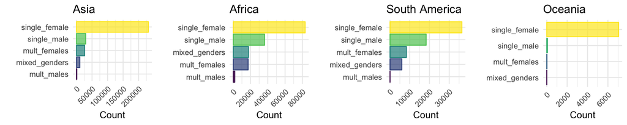

Most popular borrower genders by continent

In all continents, single females request the most loans followed by single males. In Asia and South America, the third category is multiple females while in Africa it’s mixed genders.

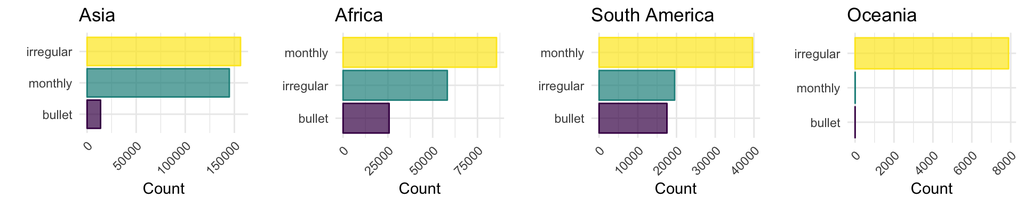

Most popular repayment styles by continent

In Asia and Oceania, the most popular repayment interval is irregular while in Africa and South America it’s monthly.

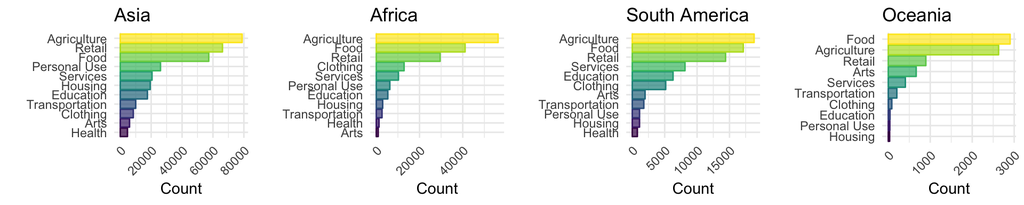

Most popular uses of loans by continent

In every continent, the three most popular sectors are agriculture, retail, and food.

Finally, we still would like to understand which countries are requesting the most loans. Let’see.

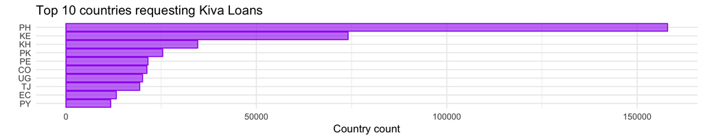

Top 10 countries requesting Kiva loans

We see that the Philippines is the country that requests the mosts loans with over double as the second country Kenya `KE`. Other top countries Cambodia `KH`, Pakistan `PK`, Peru `PE`, Colombia `CO`, Uganda `UG`, Tajikistan `TJ`, Ecuador `EC`, and Paraguay `PY`.

# Numeric variables

Now let’s look at the distributions of our numeric variables.

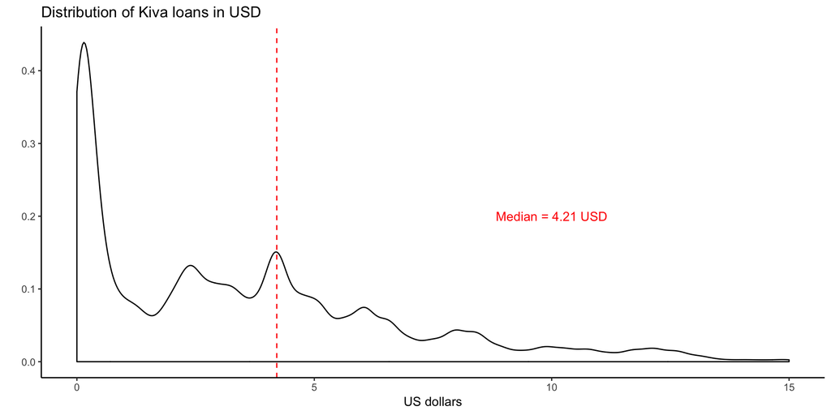

Distribution of Kiva loans in USD

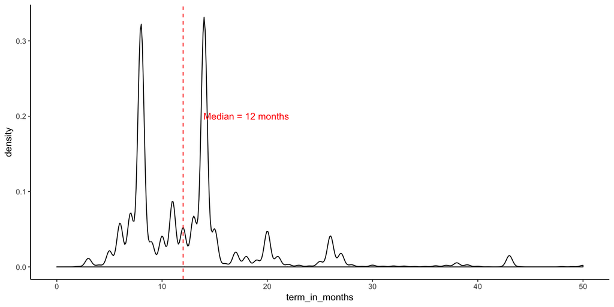

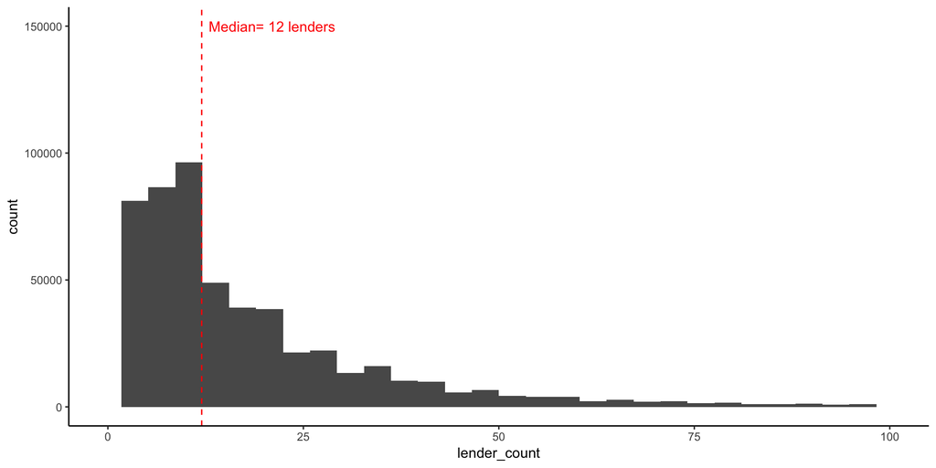

The lender count has a text book right-skewed distribution with a median of 12 lenders.

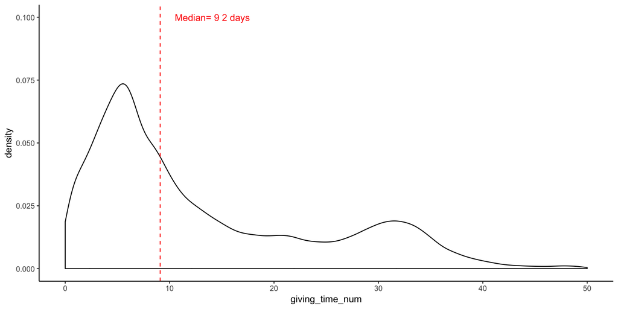

The median time between posting the loan and the loan being fully funded is about 9.2 days. It is a bimodal distribution with its first peak around 6 days and its second peak around 30 days.

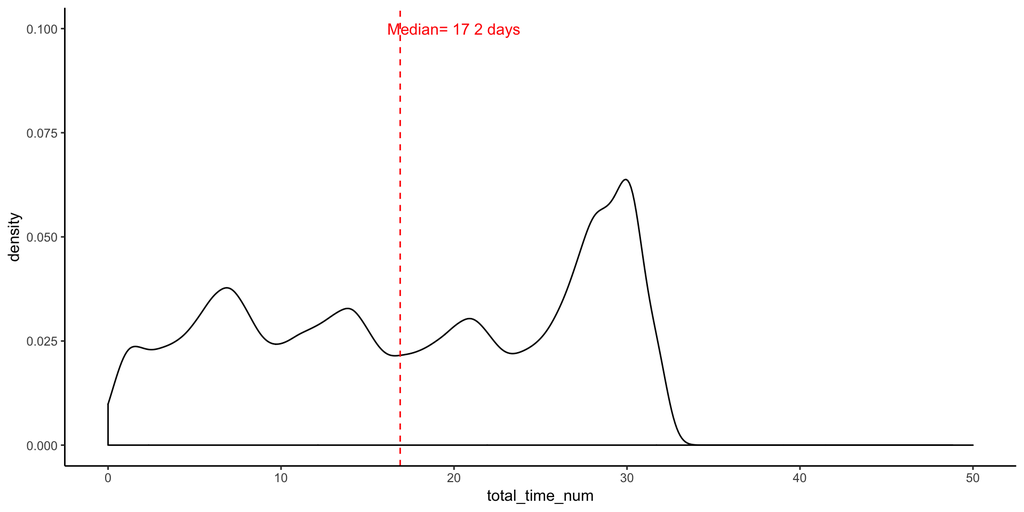

The total time between posting the loan and it being disbursed has a funky looking multimodal distribution. It seems to be cut off at 30 days with peaks at 7, 14, 21 and 30 days. Median time is 17.2 days.

# Conclusions